# Benchmarking: demultiplexing with genotyping vs HTO

2026-08-03

**Runs:** pilot `260423_VH01624_453_222HWMYNX` (where the parameter sweep was done), then ``260522, 260528, 260717` through the pipeline.

**Status:** settled. `positive.quantile = 0.99` was adopted and is what the Nextflow pipeline runs for every sample.

**Analysis finished:** 2026-07-28 - the most recent of the 46 figures shown below.

**Report generated:** 2026-08-03 by `07.demux_benchmark_report.Rmd`, from the outputs of steps 01-06 in this folder.

Samples are pooled several to a GEM well, so every cell has to be assigned back to a donor. Two independent methods are available: hashtag oligos (HTO), which are added at the bench, and genotype demultiplexing from the RNA itself via cellsnp-lite and vireo. This report compares them.

For full report, download `demux_benchmark_report.html` in the attachment and open in a browser.

Code used - attached and in the github repository: https://github.com/nbartonicek/surface_proteome_dev/tree/main/lab_archives/Benchmarking-demultiplexing_with_genotyping_vs_HTO

# Aim

Decide which demultiplexing method to carry into the pipeline, and on what setting:

- do HTO hashing and genotype demultiplexing recover the same donors
- which assigns more cells as confident singlets, and which calls more doublets
- what `positive.quantile` threshold should HTODemux use
- does the method still work for a donor that was never hashed

# Conclusions

- genotyping with cellSNP/vireo outperforms HTO hashing, and is the method the pipeline now relies on for donor assignment
- HTO is still worth running: it is what names the donors, since vireo only produces anonymous `donor0…donorN` labels that have to be matched back to sample identity
- `positive.quantile = 0.99` was adopted after the sweep and is what every pipeline run uses; the pilot’s original 0.80 is too permissive
- the unhashed-donor case works after the fix in `nextflow/bin/process_cellsnp_hto.R`, verified against LK3’s real output rather than a reimplementation

# 1. How the two methods are produced

HTO comes from CITE-seq-Count on the hashtag library (step 01), whitelisted to the emptyDrops barcodes, then `HTODemux`. Genotype demultiplexing (step 02) runs cellsnp-lite over the same barcode list against the Cell Ranger BAM, then vireo with `N_DONORS=4`. Step 03 joins the two and produces everything below.

The important asymmetry: **vireo output is anonymous.** It returns `donor0`, `donor1` … with no idea which is which. HTO is what supplies the mapping from genotype cluster to sample name, which is why both are run even though genotyping is the better classifier. That mapping is saved as `vireo_to_hto_sample_name_map_positive_quantile_0.99.csv`.

**`fig_GT_distance_estimated.pdf`**

Vireo estimated genotype distance between donors, 260423. Confirms the donors are genetically distinguishable before any comparison is made.

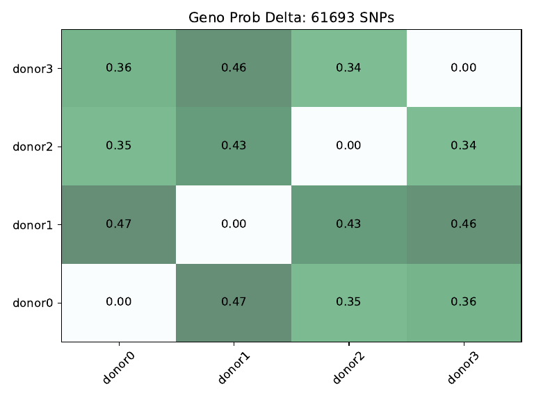

**`fig_GT_distance_estimated.pdf`**

Vireo estimated genotype distance between donors, 260522. Confirms the donors are genetically distinguishable before any comparison is made.

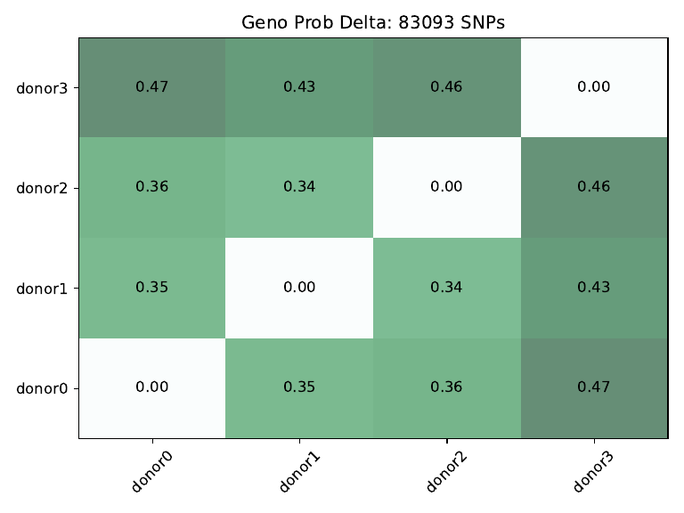

**`fig_GT_distance_estimated.pdf`**

Vireo estimated genotype distance between donors, 260528. Confirms the donors are genetically distinguishable before any comparison is made.

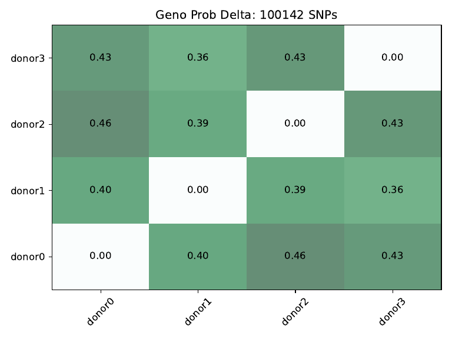

# 2. The parameter sweep

**`01_demux_efficiency_barplot.pdf`**

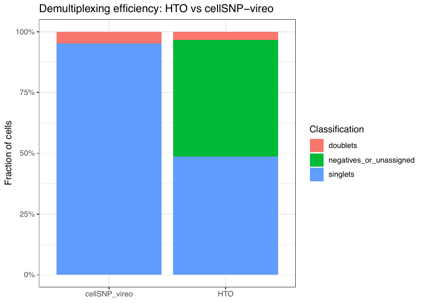

**`01_demux_efficiency_barplot_all_positive_quantiles.pdf`**

`01_demux_efficiency_barplot` across all positive quantiles.

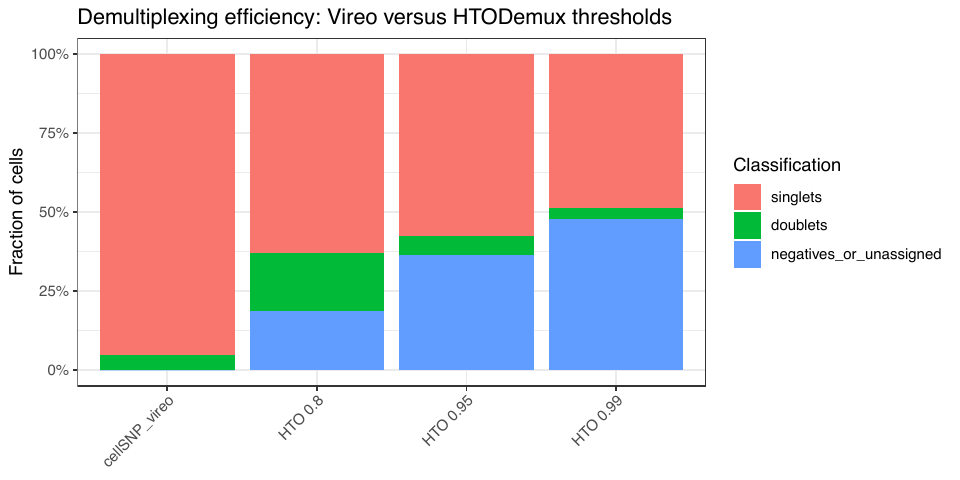

**`03_hto_vireo_donor_heatmap.pdf`**

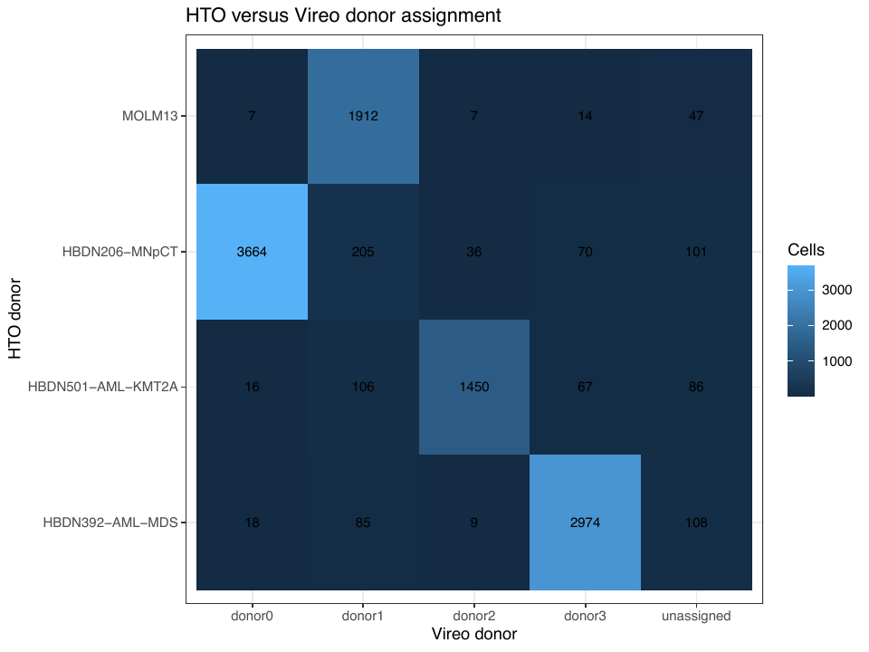

**`03_hto_vireo_donor_heatmap_all_positive_quantiles.pdf`**

`03_hto_vireo_donor_heatmap` across all positive quantiles.

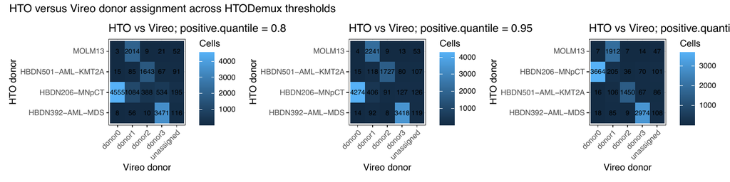

**`04_upset_HTO_vireo_overlap.pdf`**

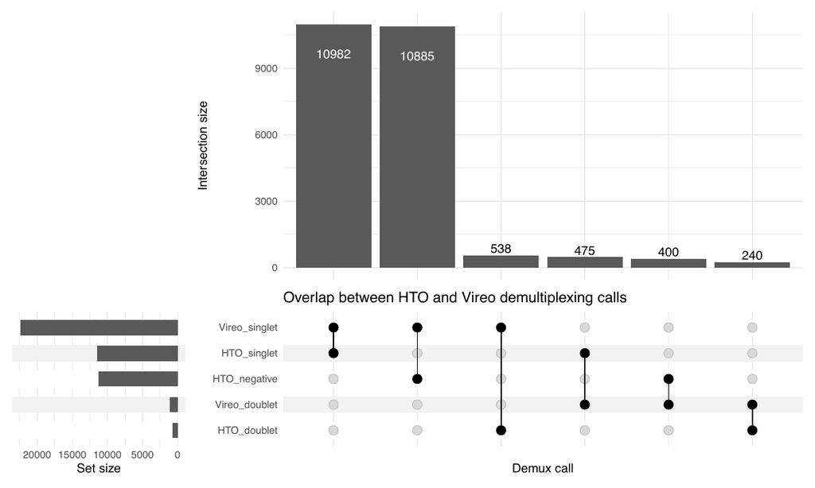

**`04_upset_HTO_vireo_overlap_all_positive_quantiles.pdf`**

`04_upset_HTO_vireo_overlap` across all positive quantiles.

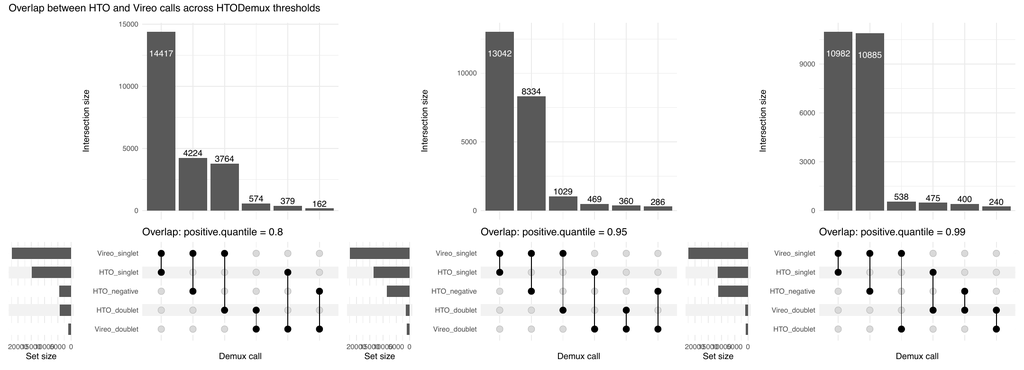

| method | total_cells | singlets | doublets | negatives_or_unassigned | singlet_fraction | doublet_fraction | negative_or_unassigned_fraction |
| --- | --- | --- | --- | --- | --- | --- | --- |
| HTO | 23520 | 11457 | 778 | 11285 | 0.4871173 | 0.0330782 | 0.4798044 |
| cellSNP_vireo | 23520 | 22405 | 1115 | 0 | 0.9525935 | 0.0474065 | 0.0000000 |

Demux efficiency across the quantile sweep

| pq_tag | method | total_cells | singlets | doublets | negatives_or_unassigned | singlet_fraction | doublet_fraction | negative_or_unassigned_fraction |
| --- | --- | --- | --- | --- | --- | --- | --- | --- |
| positive_quantile_0.8 | HTO 0.8 | 23520 | 14796 | 4338 | 4386 | 0.6290816 | 0.1844388 | 0.1864796 |
| positive_quantile_0.8 | cellSNP_vireo | 23520 | 22405 | 1115 | 0 | 0.9525935 | 0.0474065 | 0.0000000 |
| positive_quantile_0.95 | HTO 0.95 | 23520 | 13511 | 1389 | 8620 | 0.5744473 | 0.0590561 | 0.3664966 |
| positive_quantile_0.95 | cellSNP_vireo | 23520 | 22405 | 1115 | 0 | 0.9525935 | 0.0474065 | 0.0000000 |
| positive_quantile_0.99 | HTO 0.99 | 23520 | 11457 | 778 | 11285 | 0.4871173 | 0.0330782 | 0.4798044 |
| positive_quantile_0.99 | cellSNP_vireo | 23520 | 22405 | 1115 | 0 | 0.9525935 | 0.0474065 | 0.0000000 |

Only the 0.99 outputs survive for the later runs, which is the practical record of the decision: from LK2 onwards nothing else was generated.

# 3. Agreement, per run

## 260522

From the Nextflow pipeline.

Demux efficiency - 260522

| method | total_cells | singlets | doublets | negatives_or_unassigned | singlet_fraction | doublet_fraction | negative_or_unassigned_fraction |
| --- | --- | --- | --- | --- | --- | --- | --- |
| HTO | 21301 | 12529 | 736 | 8036 | 0.5881883 | 0.0345524 | 0.3772593 |
| cellSNP_vireo | 21301 | 20996 | 305 | 0 | 0.9856814 | 0.0143186 | 0.0000000 |

HTO / vireo agreement - 260522

| total_cells | both_singlet | HTO_doublet_only | Vireo_doublet_only | both_doublet | HTO_singlet_Vireo_unassigned | HTO_negative_Vireo_singlet | both_singlet_fraction | both_doublet_fraction |
| --- | --- | --- | --- | --- | --- | --- | --- | --- |
| 21301 | 12414 | 697 | 266 | 39 | 0 | 7885 | 0.5827895 | 0.0018309 |

Vireo summary - 260522

| vireo_class | vireo_donor | n_cells |
| --- | --- | --- |
| singlet | donor3 | 5737 |
| singlet | donor0 | 5681 |
| singlet | donor2 | 5658 |
| singlet | donor1 | 3046 |
| singlet | unassigned | 874 |
| doublet | doublet | 177 |
| doublet | unassigned | 128 |

## 260528

From the Nextflow pipeline.

Demux efficiency - 260528

| method | total_cells | singlets | doublets | negatives_or_unassigned | singlet_fraction | doublet_fraction | negative_or_unassigned_fraction |
| --- | --- | --- | --- | --- | --- | --- | --- |
| HTO | 33224 | 23897 | 3979 | 5348 | 0.7192692 | 0.1197628 | 0.160968 |
| cellSNP_vireo | 33224 | 31007 | 2217 | 0 | 0.9332711 | 0.0667289 | 0.000000 |

HTO / vireo agreement - 260528

| total_cells | both_singlet | HTO_doublet_only | Vireo_doublet_only | both_doublet | HTO_singlet_Vireo_unassigned | HTO_negative_Vireo_singlet | both_singlet_fraction | both_doublet_fraction |
| --- | --- | --- | --- | --- | --- | --- | --- | --- |
| 33224 | 22910 | 3265 | 1503 | 714 | 0 | 4832 | 0.6895618 | 0.0214905 |

Vireo summary - 260528

| vireo_class | vireo_donor | n_cells |
| --- | --- | --- |
| singlet | donor0 | 9953 |
| singlet | donor1 | 9443 |
| singlet | unassigned | 5317 |
| singlet | donor3 | 3994 |
| singlet | donor2 | 2300 |
| doublet | unassigned | 1139 |
| doublet | doublet | 1078 |

## 260717

From the Nextflow pipeline.

Demux efficiency - 260717

| method | total_cells | singlets | doublets | negatives_or_unassigned | singlet_fraction | doublet_fraction | negative_or_unassigned_fraction |
| --- | --- | --- | --- | --- | --- | --- | --- |
| HTO | 25926 | 15314 | 1527 | 9085 | 0.5906812 | 0.0588984 | 0.3504204 |
| cellSNP_vireo | 25926 | 24509 | 1417 | 0 | 0.9453444 | 0.0546556 | 0.0000000 |

HTO / vireo agreement - 260717

| total_cells | both_singlet | HTO_doublet_only | Vireo_doublet_only | both_doublet | HTO_singlet_Vireo_unassigned | HTO_negative_Vireo_singlet | both_singlet_fraction | both_doublet_fraction |
| --- | --- | --- | --- | --- | --- | --- | --- | --- |
| 25926 | 14652 | 1061 | 951 | 466 | 0 | 8796 | 0.565147 | 0.0179742 |

Vireo summary - 260717

| vireo_class | vireo_donor | n_cells |
| --- | --- | --- |
| singlet | donor2 | 8391 |
| singlet | donor0 | 8159 |
| singlet | donor1 | 6599 |
| singlet | unassigned | 1360 |
| doublet | doublet | 975 |
| doublet | unassigned | 442 |

# 4. The settled comparison

Figures at `positive.quantile = 0.99`, as the pipeline produces them.

## 260522

**`01_demux_efficiency_barplot_positive_quantile_0.99.pdf`**

Singlet / doublet / negative rates for HTO and vireo side by side. The headline comparison.

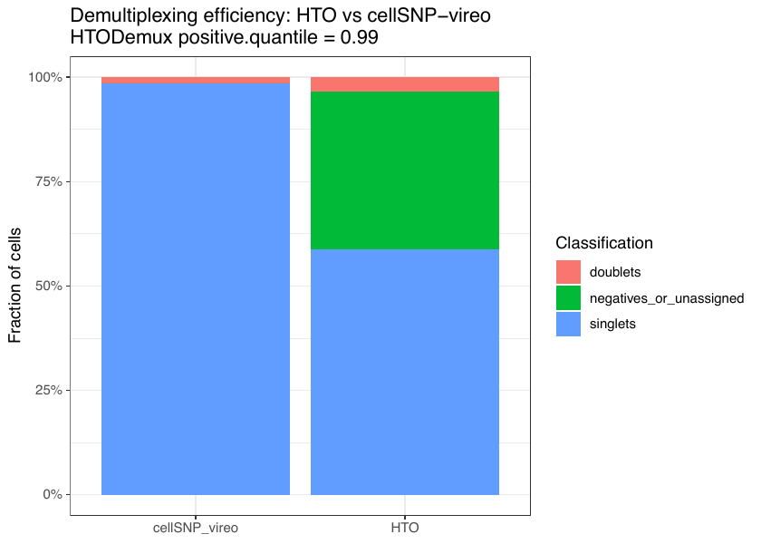

**`02_hto_vireo_doublet_comparison_positive_quantile_0.99.pdf`**

Whether the two methods call the same cells doublets.

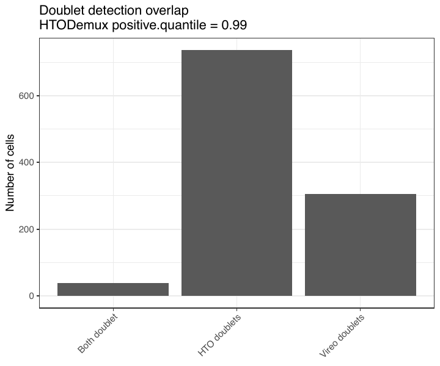

**`03_hto_vireo_donor_heatmap_positive_quantile_0.99.pdf`**

HTO sample against vireo donor. Off-diagonal mass is the disagreement; this is also the figure the sample-name mapping is read off.

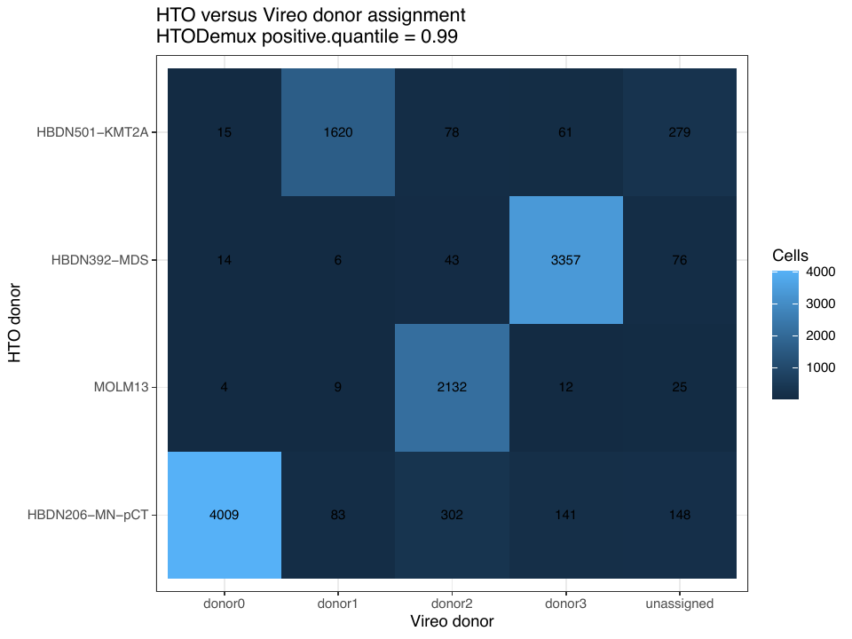

**`04_upset_HTO_vireo_overlap_positive_quantile_0.99.pdf`**

UpSet of the call overlap.

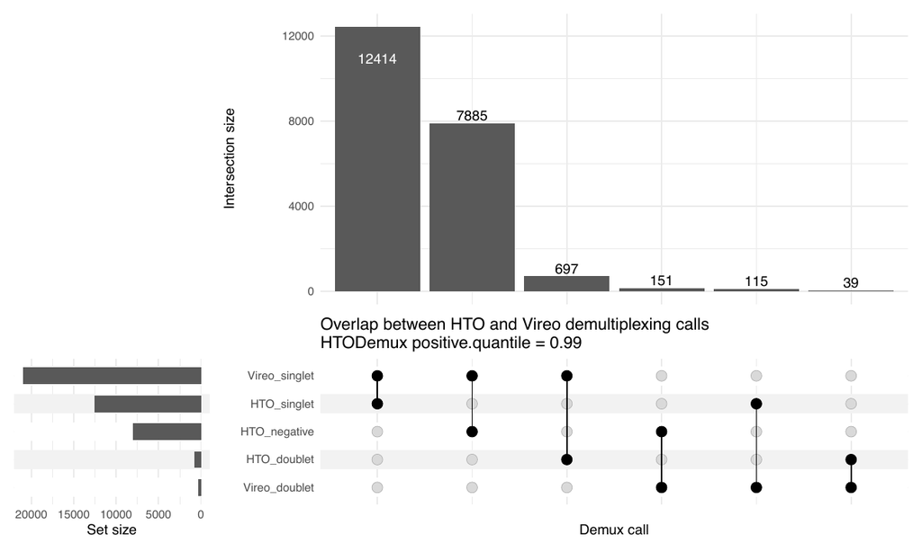

**`05_HTO_QC_positive_quantile_0.99.pdf`**

HTO QC at the adopted threshold.

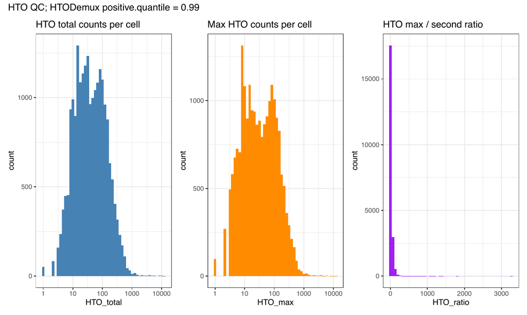

**`06_HTO_ridge_positive_quantile_0.99.pdf`**

Ridge plots per hashtag.

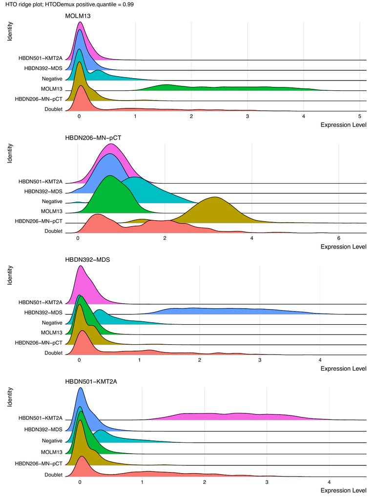

**`06b_HTO_ratio_thresholds_positive_quantile_0.99.pdf`**

HTO ratio thresholds.

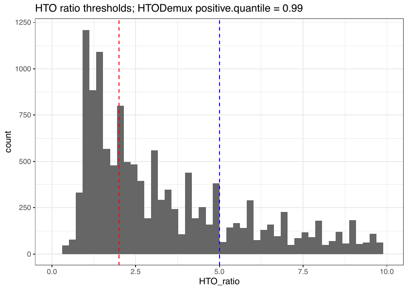

**`07_UMAP_HTO_cellSNP_positive_quantile_0.99.pdf`**

Both sets of calls on the UMAP.

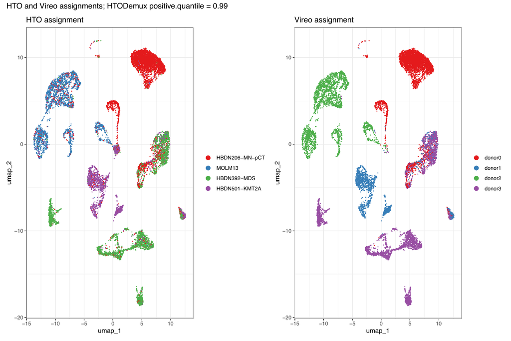

## 260528

**`01_demux_efficiency_barplot_positive_quantile_0.99.pdf`**

Singlet / doublet / negative rates for HTO and vireo side by side. The headline comparison.

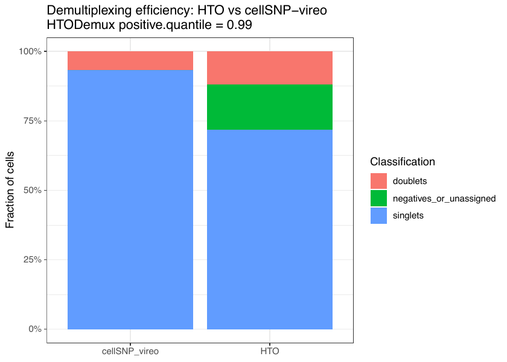

**`02_hto_vireo_doublet_comparison_positive_quantile_0.99.pdf`**

Whether the two methods call the same cells doublets.

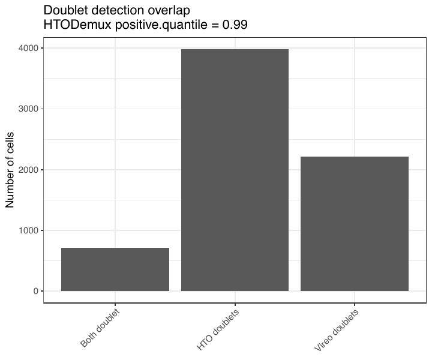

**`03_hto_vireo_donor_heatmap_positive_quantile_0.99.pdf`**

HTO sample against vireo donor. Off-diagonal mass is the disagreement; this is also the figure the sample-name mapping is read off.

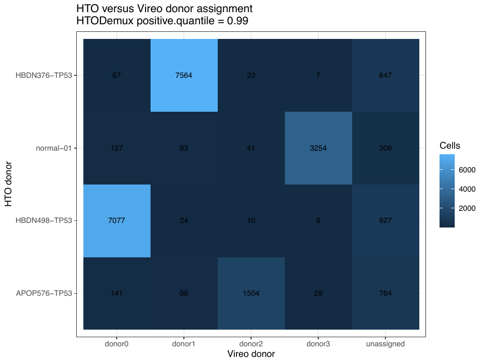

**`04_upset_HTO_vireo_overlap_positive_quantile_0.99.pdf`**

UpSet of the call overlap.

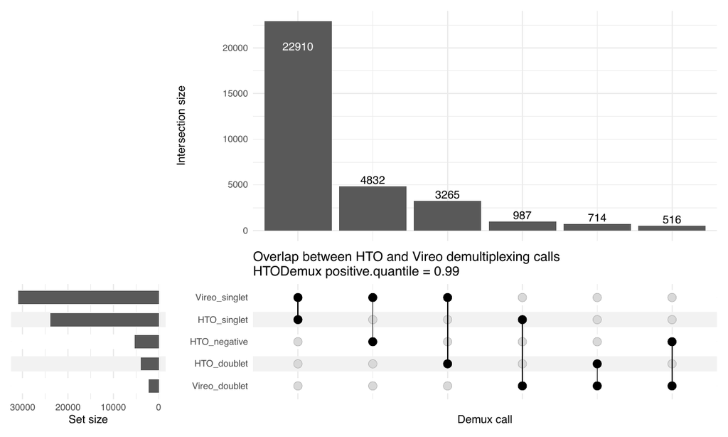

**`05_HTO_QC_positive_quantile_0.99.pdf`**

HTO QC at the adopted threshold.

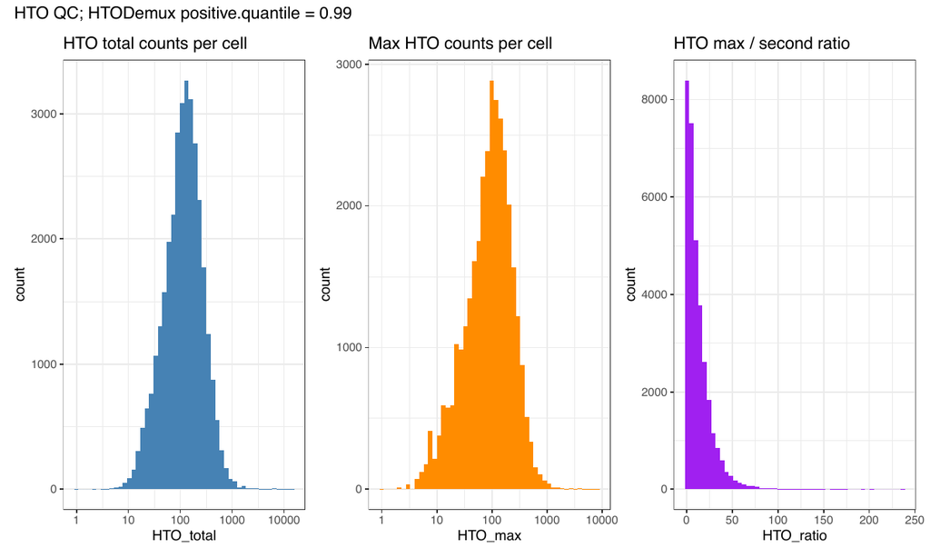

**`06_HTO_ridge_positive_quantile_0.99.pdf`**

Ridge plots per hashtag.

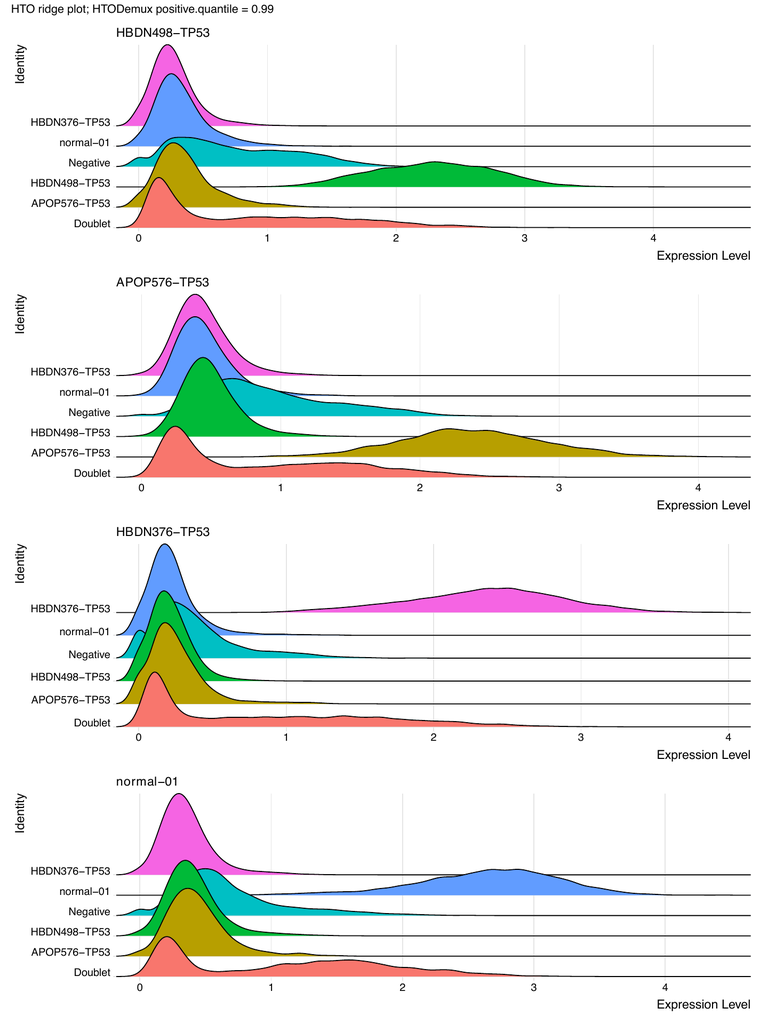

**`06b_HTO_ratio_thresholds_positive_quantile_0.99.pdf`**

HTO ratio thresholds.

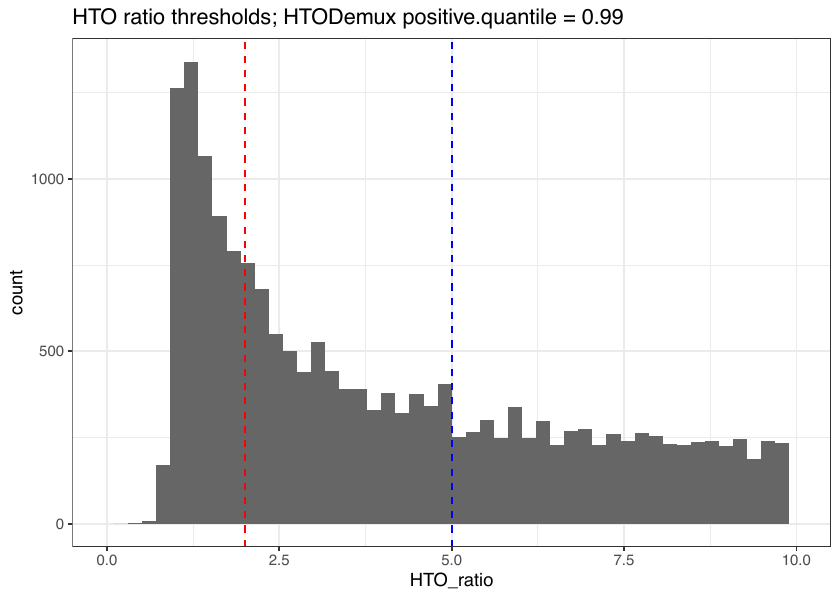

**`07_UMAP_HTO_cellSNP_positive_quantile_0.99.pdf`**

Both sets of calls on the UMAP.

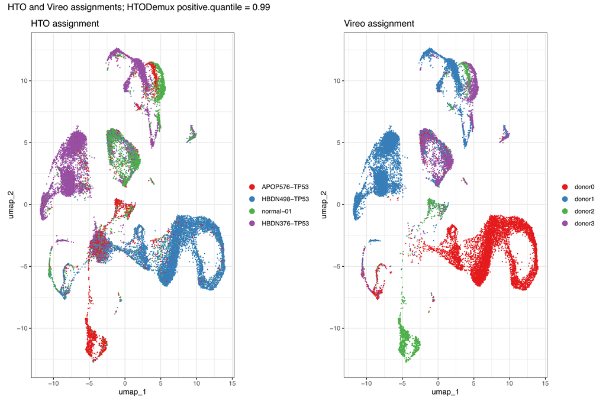

## 260717

**`01_demux_efficiency_barplot_positive_quantile_0.99.pdf`**

Singlet / doublet / negative rates for HTO and vireo side by side. The headline comparison.

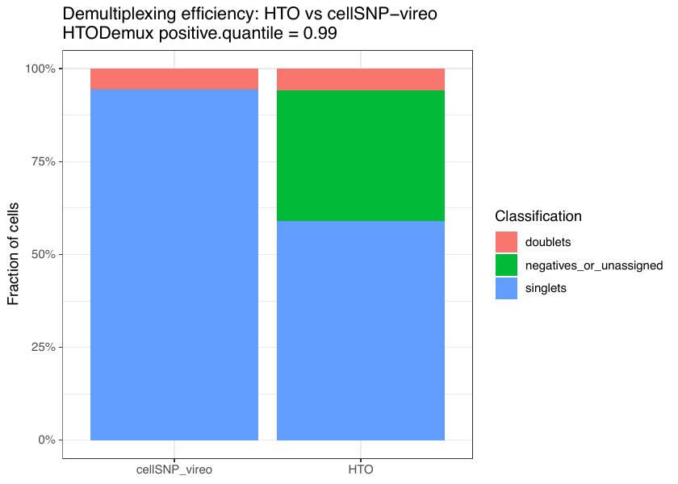

**`02_hto_vireo_doublet_comparison_positive_quantile_0.99.pdf`**

Whether the two methods call the same cells doublets.

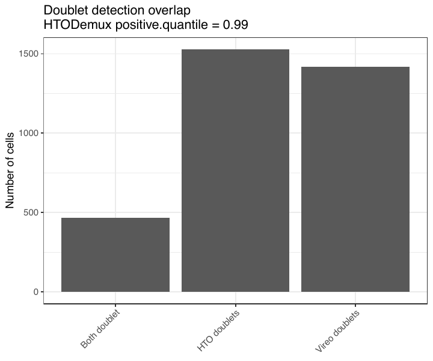

**`03_hto_vireo_donor_heatmap_positive_quantile_0.99.pdf`**

HTO sample against vireo donor. Off-diagonal mass is the disagreement; this is also the figure the sample-name mapping is read off.

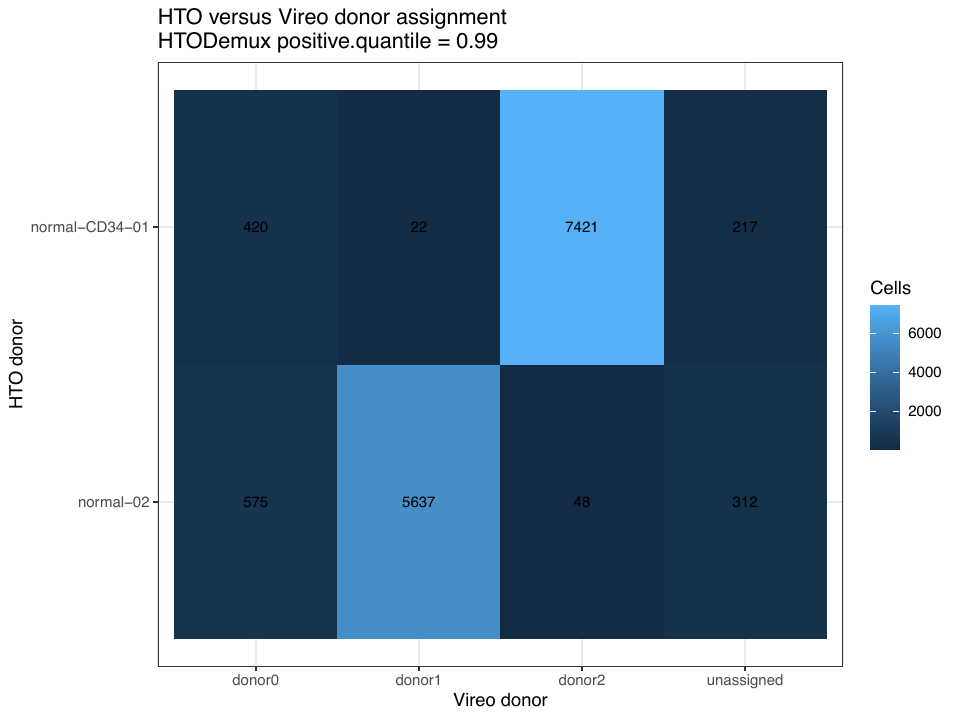

**`04_upset_HTO_vireo_overlap_positive_quantile_0.99.pdf`**

UpSet of the call overlap.

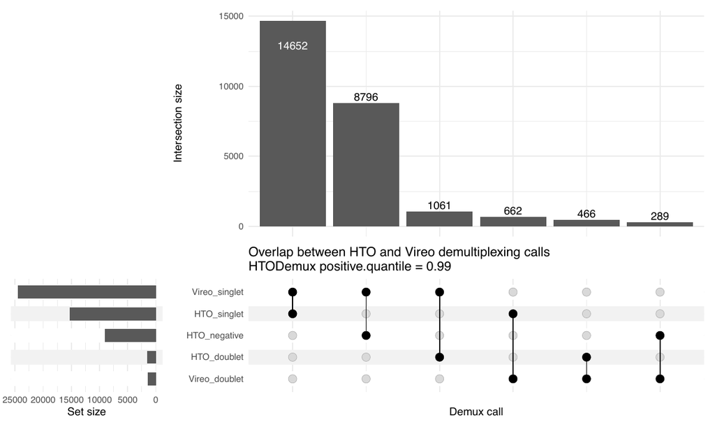

**`05_HTO_QC_positive_quantile_0.99.pdf`**